# Heart Disease Predictive Project

Page Freeman, Tianji Lukins, Pat Kavanagh

2023-10-29

Load the data

```r
heart.df <- read.csv("Heart_Disease_Prediction.csv")
```

Exploration/cleaning of data

```r
#looking at dataset
head(heart.df)
```

```
##   index Age Sex Chest.pain.type  BP Cholesterol FBS.over.120 EKG.results Max.HR
## 1     0  70   1               4 130         322            0           2    109
## 2     1  67   0               3 115         564            0           2    160
## 3     2  57   1               2 124         261            0           0    141
## 4     3  64   1               4 128         263            0           0    105
## 5     4  74   0               2 120         269            0           2    121
## 6     5  65   1               4 120         177            0           0    140
##   Exercise.angina ST.depression Slope.of.ST Number.of.vessels.fluro Thallium
## 1               0           2.4           2                       3        3
## 2               0           1.6           2                       0        7
## 3               0           0.3           1                       0        7
## 4               1           0.2           2                       1        7
## 5               1           0.2           1                       1        3
## 6               0           0.4           1                       0        7
##   Heart.Disease
## 1      Presence
## 2       Absence
## 3      Presence
## 4       Absence
## 5       Absence
## 6       Absence
```

```r
tail(heart.df)
```

```
##     index Age Sex Chest.pain.type  BP Cholesterol FBS.over.120 EKG.results
## 265   264  48   1               2 110         229            0           0
## 266   265  52   1               3 172         199            1           0
## 267   266  44   1               2 120         263            0           0
## 268   267  56   0               2 140         294            0           2
## 269   268  57   1               4 140         192            0           0
## 270   269  67   1               4 160         286            0           2
##     Max.HR Exercise.angina ST.depression Slope.of.ST Number.of.vessels.fluro
## 265    168               0           1.0           3                       0
## 266    162               0           0.5           1                       0
## 267    173               0           0.0           1                       0
## 268    153               0           1.3           2                       0
## 269    148               0           0.4           2                       0
## 270    108               1           1.5           2                       3
##     Thallium Heart.Disease
## 265        7      Presence
## 266        7       Absence
## 267        7       Absence
## 268        3       Absence
## 269        6       Absence
## 270        3      Presence
```

```r
dim(heart.df)
```

```
## [1] 270  15
```

```r
#taking out index column
heart.df <- heart.df[ , -1]

#checking for NA values
sum(is.na(heart.df)) #0
```

```
## [1] 0
```

```r
#Renaming columns to take out spaces
names(heart.df) <- gsub("\\s+", ".", names(heart.df))
```

Introduction to data

```r
#Variable names
t(t(names(heart.df)))
```

```
##       [,1]
##  [1,] "Age"
##  [2,] "Sex"
##  [3,] "Chest.pain.type"
##  [4,] "BP"
##  [5,] "Cholesterol"
##  [6,] "FBS.over.120"
##  [7,] "EKG.results"
##  [8,] "Max.HR"
##  [9,] "Exercise.angina"
## [10,] "ST.depression"
## [11,] "Slope.of.ST"
## [12,] "Number.of.vessels.fluro"
## [13,] "Thallium"
## [14,] "Heart.Disease"
```

```r
#summary stats of variables: age, BP, Cholesterol
summary(heart.df$Age)
```

```
##    Min. 1st Qu.  Median    Mean 3rd Qu.    Max.
##   29.00   48.00   55.00   54.43   61.00   77.00
```

```r
summary(heart.df$BP)
```

```
##    Min. 1st Qu.  Median    Mean 3rd Qu.    Max.
##    94.0   120.0   130.0   131.3   140.0   200.0
```

```r
summary(heart.df$Cholesterol)
```

```
##    Min. 1st Qu.  Median    Mean 3rd Qu.    Max.
##   126.0   213.0   245.0   249.7   280.0   564.0
```

Factoring the Cateogrical variables (Data Reduction)

```r
#creating duplicate dataframe with categorical dummy variables
heart.df1 <- heart.df

#sex - column 2
heart.df$Sex <- factor(heart.df$Sex, levels = c(0,1),
                                   labels = c("Female", "Male"))

#chest pain type - column 3
heart.df$Chest.pain.type <- factor(heart.df$Chest.pain.type, levels = c(1,2,3,4),
                                   labels = c("Typical Angina", "Atypical Angina", "Non-Anginal Pain", "Asymptomatic"))
#EKG results -
heart.df$EKG.results <- factor(heart.df$EKG.results, levels = c(0,2),
                                   labels = c("Normal","Abnormal"))

#FBS over 120
heart.df$FBS.over.120 <- factor(heart.df$FBS.over.120, levels = c(0,1),
                                   labels = c("False", "True"))

#Exercise angina
heart.df$Exercise.angina <- factor(heart.df$Exercise.angina, levels = c(0,1),
                                   labels = c("No", "Yes"))

#Slope of ST
heart.df$Slope.of.ST <- factor(heart.df$Slope.of.ST, levels = c(1,2,3),
                                   labels = c("Flat", "Upsloping", "Downsloping"))

#thallium
heart.df$Thallium <- factor(heart.df$Thallium, levels = c(3,6,7),
                            labels = c("Normal", "Fixed defect", "Reversible defect"))


#Heart disease
heart.df$Heart.Disease <- ifelse(heart.df$Heart.Disease == "Presence", 1, 0)

#2 NAs in EKG results that are not normal or abnormal - removing these 2 rows
sum(is.na(heart.df$EKG.results))
```

```
## [1] 2
```

```r
heart.df <- na.omit(heart.df)
```

Data Visualization

bar graphs - categorical variables scatterplot - relationship between numerical histogram - distribution of outcome variable boxplot - side by side is useful for comparing

Basic graphs for visualization

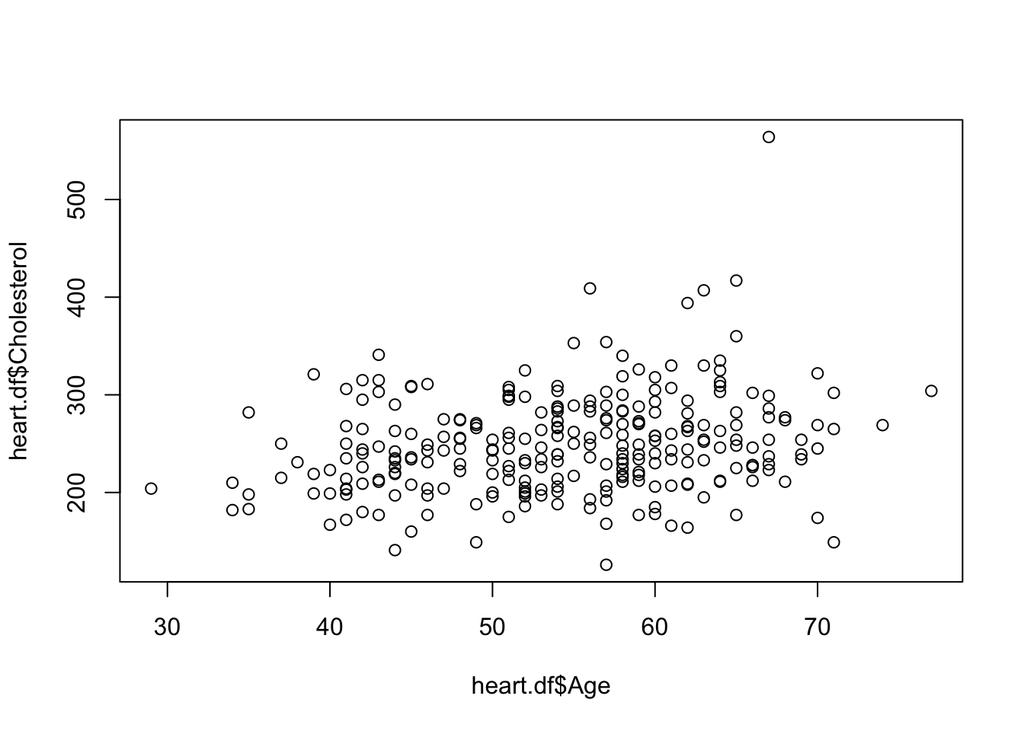

```r
#Scatter plots
  #somewhat positive correlation
plot(heart.df$Age, heart.df$Cholesterol)
```

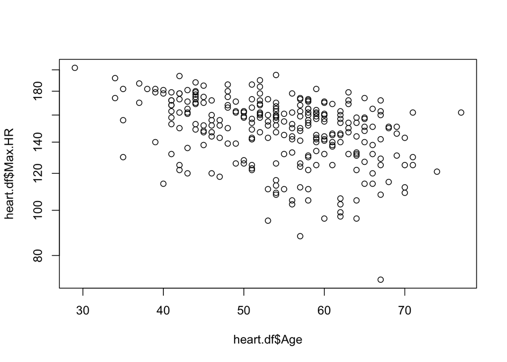

```r
  #somewhat negative correlation
plot(heart.df$Age, heart.df$Max.HR, log = "y")
```

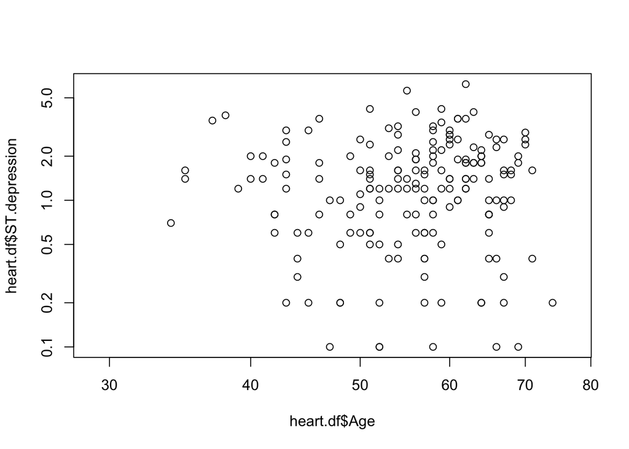

```r
  #all over the place
plot(heart.df$Age, heart.df$ST.depression, log = "xy")
```

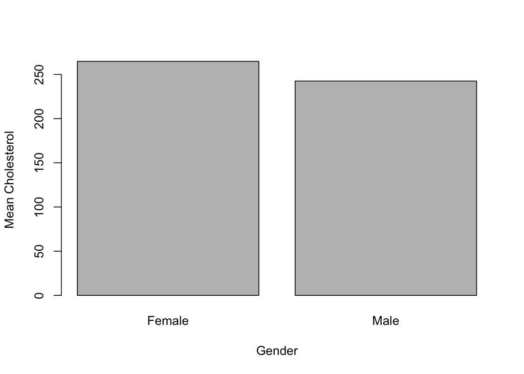

```r
#bar chart to show mean cholesterol for gender
data.for.plot <- aggregate(heart.df$Cholesterol, by = list(heart.df$Sex), FUN = mean)
names(data.for.plot) <- c("Sex", "Cholesterol")
barplot(data.for.plot$Cholesterol, names.arg = data.for.plot$Sex, xlab = "Gender", ylab = "Mean Cholesterol")
```

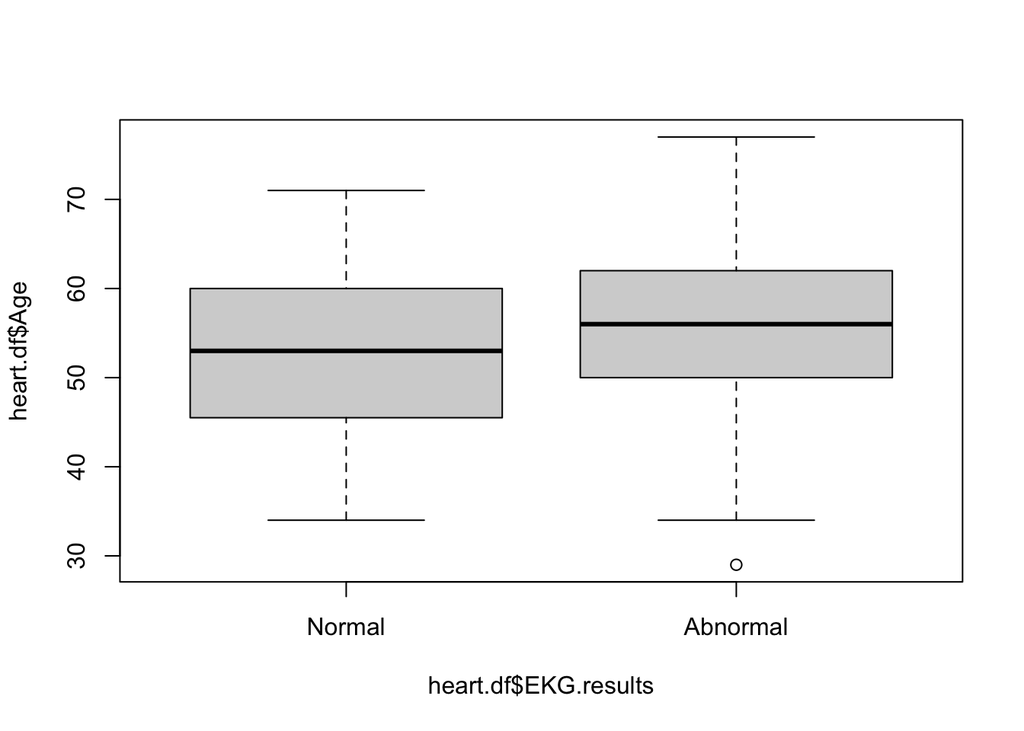

```r
#Boxplot
boxplot(heart.df$Age ~ heart.df$EKG.results)
```

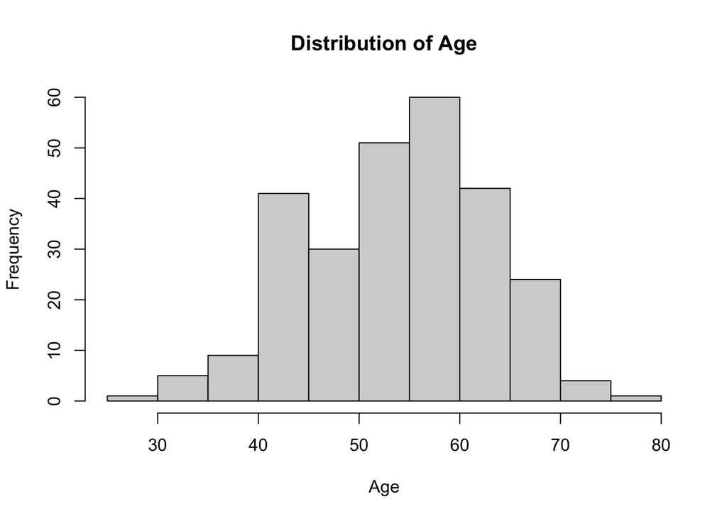

```r
#Historgram of Age
hist(heart.df$Age, xlab = "Age", main = "Distribution of Age")
```

Predictive Performance

- looking at how predictors can predict presence of heart disease and accuracy based on actual records

```r
library(forecast)
#categorical variables = -c(2,3,6, 7, 9, 11, 13, 14)

#training and validation datasets - 60% training/ 40% validation
set.seed(123)
train.rows <- sample(1:dim(heart.df)[1], 162)
#taking out heart disease presence column
train.df<-heart.df[train.rows,]


valid.df <- heart.df[-train.rows,]


#logistic reg model for all predictors of heart disease
logit.reg <- glm(Heart.Disease ~ ., data = train.df, family = "binomial")
options(scipen=999)
summary(logit.reg)
```

```
##
## Call:
## glm(formula = Heart.Disease ~ ., family = "binomial", data = train.df)
##
## Deviance Residuals:
##     Min       1Q   Median       3Q      Max
## -2.9316  -0.3830  -0.1139   0.2554   3.0890
##
## Coefficients:
##                                   Estimate Std. Error z value Pr(>|z|)
## (Intercept)                     -10.364447   4.630521  -2.238  0.02520 *
## Age                              -0.007351   0.038662  -0.190  0.84920
## SexMale                           1.563742   0.844261   1.852  0.06400 .
## Chest.pain.typeAtypical Angina   -0.358767   1.230975  -0.291  0.77071
## Chest.pain.typeNon-Anginal Pain  -0.699887   1.105543  -0.633  0.52669
## Chest.pain.typeAsymptomatic       1.252079   0.972282   1.288  0.19782
## BP                                0.027684   0.017868   1.549  0.12131
## Cholesterol                       0.015082   0.007508   2.009  0.04455 *
## FBS.over.120True                 -1.488198   0.965431  -1.541  0.12320
## EKG.resultsAbnormal               1.043830   0.645486   1.617  0.10585
## Max.HR                           -0.010335   0.016324  -0.633  0.52667
## Exercise.anginaYes                0.436604   0.641555   0.681  0.49616
## ST.depression                     0.093387   0.358863   0.260  0.79469
## Slope.of.STUpsloping              1.758637   0.731683   2.404  0.01624 *
## Slope.of.STDownsloping            2.323000   1.440793   1.612  0.10690
## Number.of.vessels.fluro           1.261899   0.425462   2.966  0.00302 **
## ThalliumFixed defect              0.159420   1.084864   0.147  0.88317
## ThalliumReversible defect         2.401936   0.760980   3.156  0.00160 **
## ---
## Signif. codes:  0 '***' 0.001 '**' 0.01 '*' 0.05 '.' 0.1 ' ' 1
##
## (Dispersion parameter for binomial family taken to be 1)
##
##     Null deviance: 222.104  on 161  degrees of freedom
## Residual deviance:  89.001  on 144  degrees of freedom
## AIC: 125
##
## Number of Fisher Scoring iterations: 6
```

```r
#most significant (** NOT ***) is thallium reversible defect and # of vessels fluoro

# use predict() with type = "response" to compute predicted probabilities.
logit.reg.pred <- predict(logit.reg, valid.df[, -14], type = "response")

#first 10 records with actual and predicted records
data.frame(actual = valid.df$Heart.Disease[1:10], predicted = logit.reg.pred[1:10])
```

```
##    actual predicted
## 2       0 0.9788164
## 3       1 0.2250226
## 8       1 0.9854402
## 9       1 0.9983217
## 10      1 0.9997940
## 11      0 0.8614569
## 12      0 0.8944027
## 15      0 0.3196004
## 18      1 0.9171203
## 19      0 0.2451269
```

```r
#assigning predicted class = 1 for predicted probability > cutoff and 0 otherwise (cutoff = 0.5)
cutoff <- 0.5
pred_class <- ifelse(logit.reg.pred> cutoff, 1, 0)
options(scipen=999)
head(data.frame(logit.reg.pred, pred_class, valid.df$Heart.Disease), 10)
```

```
##    logit.reg.pred pred_class valid.df.Heart.Disease
## 2       0.9788164          1                      0
## 3       0.2250226          0                      1
## 8       0.9854402          1                      1
## 9       0.9983217          1                      1
## 10      0.9997940          1                      1
## 11      0.8614569          1                      0
## 12      0.8944027          1                      0
## 15      0.3196004          0                      0
## 18      0.9171203          1                      1
## 19      0.2451269          0                      0
```

```r
#confusion matrix
library(caret)
confusionMatrix(as.factor(pred_class), as.factor(valid.df$Heart.Disease))
```

```
## Confusion Matrix and Statistics
##
##           Reference
## Prediction  0  1
##          0 47 11
##          1 11 37
##
##                Accuracy : 0.7925
##                  95% CI : (0.7028, 0.8651)
##     No Information Rate : 0.5472
##     P-Value [Acc > NIR] : 0.00000012
##
##                   Kappa : 0.5812
##
##  Mcnemar's Test P-Value : 1
##
##             Sensitivity : 0.8103
##             Specificity : 0.7708
##          Pos Pred Value : 0.8103
##          Neg Pred Value : 0.7708
##              Prevalence : 0.5472
##          Detection Rate : 0.4434
##    Detection Prevalence : 0.5472
##       Balanced Accuracy : 0.7906
##
##        'Positive' Class : 0
##
```

```r
#accuracy of 0.7925

#We would rather have false positives (high specificity = less false positives) and NO false negatives (high sensitivity = less false negatives). In this context, false negatives are people we say don't have heart disease when they do and that is worse than saying that have heart disease when they don't (false positive)

#specificity = 0.7708
#sensitivity = 0.8103
```

Finding the most important predictors in our logistic regression model – to solve multicollinearity, removing extreme redundancies by dropping predictors via variable selection

```r
#selecting subsets of predictors

library(leaps)

#Exhaustive search -
exhaustive.search <- regsubsets(Heart.Disease ~., data = train.df, nvmax = dim(train.df)[2], method = "exhaustive")
sum <- summary(exhaustive.search)
sum
```

```
## Subset selection object
## Call: regsubsets.formula(Heart.Disease ~ ., data = train.df, nvmax = dim(train.df)[2],
##     method = "exhaustive")
## 17 Variables  (and intercept)
##                                 Forced in Forced out
## Age                                 FALSE      FALSE
## SexMale                             FALSE      FALSE
## Chest.pain.typeAtypical Angina      FALSE      FALSE
## Chest.pain.typeNon-Anginal Pain     FALSE      FALSE
## Chest.pain.typeAsymptomatic         FALSE      FALSE
## BP                                  FALSE      FALSE
## Cholesterol                         FALSE      FALSE
## FBS.over.120True                    FALSE      FALSE
## EKG.resultsAbnormal                 FALSE      FALSE
## Max.HR                              FALSE      FALSE
```

[output cut: 99 more lines]

```r
sum$which
```

```
##    (Intercept)   Age SexMale Chest.pain.typeAtypical Angina
## 1         TRUE FALSE   FALSE                          FALSE
## 2         TRUE FALSE   FALSE                          FALSE
## 3         TRUE FALSE   FALSE                          FALSE
## 4         TRUE FALSE   FALSE                          FALSE
## 5         TRUE FALSE    TRUE                          FALSE
## 6         TRUE FALSE    TRUE                          FALSE
## 7         TRUE FALSE    TRUE                          FALSE
## 8         TRUE FALSE    TRUE                          FALSE
## 9         TRUE FALSE    TRUE                          FALSE
## 10        TRUE FALSE    TRUE                          FALSE
## 11        TRUE FALSE    TRUE                          FALSE
## 12        TRUE FALSE    TRUE                          FALSE
## 13        TRUE FALSE    TRUE                          FALSE
## 14        TRUE FALSE    TRUE                          FALSE
```

[output cut: 60 more lines]

```r
sum$adjr2
```

```
##  [1] 0.3539534 0.4401137 0.4962206 0.5305294 0.5387942 0.5497524 0.5602129
##  [8] 0.5613994 0.5632966 0.5650698 0.5651097 0.5641196 0.5627130 0.5608813
```

```r
#based on exhaustive, pick 11 predictors


#forward selection
#model with no predictors for bottom of range search
heart.lm.null <- glm(Heart.Disease~1, data = train.df)

#step() to run forward selection
forward <- step(heart.lm.null, scope = list(lower = heart.lm.null, upper = logit.reg), direction = "forward")
```

```
## Start:  AIC=236.67
## Heart.Disease ~ 1
##
##                           Df Deviance    AIC
## + Thallium                 2   24.453 161.42
## + Chest.pain.type          3   29.789 195.39
## + Number.of.vessels.fluro  1   31.170 198.74
## + ST.depression            1   32.950 207.74
## + Slope.of.ST              2   32.638 208.19
## + Max.HR                   1   33.045 208.20
## + Exercise.angina          1   34.173 213.64
## + Sex                      1   36.380 223.78
## + EKG.results              1   38.373 232.42
## + BP                       1   38.663 233.64
## + Age                      1   38.707 233.82
## + Cholesterol              1   39.079 235.37
## <none>                         39.883 236.67
## + FBS.over.120             1   39.876 238.64
##
## Step:  AIC=161.42
## Heart.Disease ~ Thallium
##
##                           Df Deviance    AIC
## + Number.of.vessels.fluro  1   21.230 140.52
## + Chest.pain.type          3   21.281 144.91
## + Slope.of.ST              2   22.416 151.33
## + EKG.results              1   22.788 151.99
## + Max.HR                   1   22.872 152.59
## + ST.depression            1   22.934 153.03
## + Exercise.angina          1   23.484 156.87
## + Cholesterol              1   23.576 157.50
## + Age                      1   23.675 158.18
## <none>                         24.453 161.42
## + BP                       1   24.229 161.93
## + Sex                      1   24.277 162.25
## + FBS.over.120             1   24.438 163.32
##
## Step:  AIC=140.52
## Heart.Disease ~ Thallium + Number.of.vessels.fluro
##
```

[output cut: 59 more lines]

```
## + Age              1   17.056 119.06
##
## Step:  AIC=113.85
## Heart.Disease ~ Thallium + Number.of.vessels.fluro + Chest.pain.type +
##     Slope.of.ST + Cholesterol + Sex
##
##                   Df Deviance    AIC
## <none>                 16.516 113.85
## + EKG.results      1   16.357 114.28
## + FBS.over.120     1   16.397 114.68
## + Exercise.angina  1   16.436 115.06
## + BP               1   16.438 115.08
## + ST.depression    1   16.448 115.18
## + Max.HR           1   16.463 115.33
## + Age              1   16.510 115.79
```

```r
summary(forward)
```

```
##
## Call:
## glm(formula = Heart.Disease ~ Thallium + Number.of.vessels.fluro +
##     Chest.pain.type + Slope.of.ST + Cholesterol + Sex, data = train.df)
##
## Deviance Residuals:
##      Min        1Q    Median        3Q       Max
## -0.98609  -0.21387  -0.00445   0.19913   0.99738
##
## Coefficients:
##                                   Estimate Std. Error t value   Pr(>|t|)
## (Intercept)                     -0.3550304  0.1818346  -1.952   0.052729 .
## ThalliumFixed defect             0.1183318  0.1249352   0.947   0.345078
## ThalliumReversible defect        0.3465998  0.0694255   4.992 0.00000163 ***
## Number.of.vessels.fluro          0.1193896  0.0299977   3.980   0.000107 ***
## Chest.pain.typeAtypical Angina  -0.0923559  0.1157514  -0.798   0.426192
## Chest.pain.typeNon-Anginal Pain -0.1375372  0.1096611  -1.254   0.211707
## Chest.pain.typeAsymptomatic      0.1253930  0.1065382   1.177   0.241057
## Slope.of.STUpsloping             0.2250923  0.0585112   3.847   0.000176 ***
## Slope.of.STDownsloping           0.2256531  0.1058173   2.132   0.034585 *
## Cholesterol                      0.0014729  0.0005801   2.539   0.012127 *
## SexMale                          0.1372835  0.0613644   2.237   0.026739 *
## ---
## Signif. codes:  0 '***' 0.001 '**' 0.01 '*' 0.05 '.' 0.1 ' ' 1
##
## (Dispersion parameter for gaussian family taken to be 0.1093785)
##
##     Null deviance: 39.883  on 161  degrees of freedom
## Residual deviance: 16.516  on 151  degrees of freedom
## AIC: 113.85
##
## Number of Fisher Scoring iterations: 2
```

```r
#6 predictors

#Backward Selection
backward <- step(logit.reg, direction = "backward")
```

```
## Start:  AIC=125
## Heart.Disease ~ Age + Sex + Chest.pain.type + BP + Cholesterol +
##     FBS.over.120 + EKG.results + Max.HR + Exercise.angina + ST.depression +
##     Slope.of.ST + Number.of.vessels.fluro + Thallium
##
##                           Df Deviance    AIC
## - Age                      1   89.038 123.04
## - ST.depression            1   89.069 123.07
## - Max.HR                   1   89.402 123.40
## - Exercise.angina          1   89.460 123.46
## <none>                         89.001 125.00
## - FBS.over.120             1   91.496 125.50
## - BP                       1   91.559 125.56
## - EKG.results              1   91.781 125.78
## - Sex                      1   92.640 126.64
## - Chest.pain.type          3   97.411 127.41
## - Cholesterol              1   93.531 127.53
## - Slope.of.ST              2   95.789 127.79
## - Number.of.vessels.fluro  1  100.444 134.44
## - Thallium                 2  102.709 134.71
##
## Step:  AIC=123.04
## Heart.Disease ~ Sex + Chest.pain.type + BP + Cholesterol + FBS.over.120 +
##     EKG.results + Max.HR + Exercise.angina + ST.depression +
##     Slope.of.ST + Number.of.vessels.fluro + Thallium
##
##                           Df Deviance    AIC
## - ST.depression            1   89.114 121.11
## - Max.HR                   1   89.405 121.41
## - Exercise.angina          1   89.531 121.53
## <none>                         89.038 123.04
## - BP                       1   91.605 123.61
## - FBS.over.120             1   91.702 123.70
## - EKG.results              1   91.849 123.85
## - Sex                      1   92.909 124.91
## - Chest.pain.type          3   97.411 125.41
## - Cholesterol              1   93.535 125.53
## - Slope.of.ST              2   95.989 125.99
## - Number.of.vessels.fluro  1  100.862 132.86
## - Thallium                 2  103.141 133.14
```

[output cut: 38 more lines]

```
## Step:  AIC=118.21
## Heart.Disease ~ Sex + Chest.pain.type + BP + Cholesterol + FBS.over.120 +
##     EKG.results + Slope.of.ST + Number.of.vessels.fluro + Thallium
##
##                           Df Deviance    AIC
## <none>                         90.215 118.22
## - BP                       1   92.844 118.84
## - EKG.results              1   93.229 119.23
## - FBS.over.120             1   93.279 119.28
## - Sex                      1   93.818 119.82
## - Cholesterol              1   94.751 120.75
## - Chest.pain.type          3  101.175 123.17
## - Slope.of.ST              2  105.033 129.03
## - Number.of.vessels.fluro  1  104.308 130.31
## - Thallium                 2  106.995 131.00
```

```r
summary(backward)
```

```
##
## Call:
## glm(formula = Heart.Disease ~ Sex + Chest.pain.type + BP + Cholesterol +
##     FBS.over.120 + EKG.results + Slope.of.ST + Number.of.vessels.fluro +
##     Thallium, family = "binomial", data = train.df)
##
## Deviance Residuals:
##     Min       1Q   Median       3Q      Max
## -2.8193  -0.3820  -0.1096   0.3061   3.1468
##
## Coefficients:
##                                   Estimate Std. Error z value Pr(>|z|)
## (Intercept)                     -11.941790   3.473145  -3.438 0.000585 ***
## SexMale                           1.416927   0.767010   1.847 0.064698 .
## Chest.pain.typeAtypical Angina   -0.690661   1.164962  -0.593 0.553274
## Chest.pain.typeNon-Anginal Pain  -0.832634   1.093652  -0.761 0.446458
## Chest.pain.typeAsymptomatic       1.224641   0.933238   1.312 0.189436
## BP                                0.027093   0.017242   1.571 0.116094
## Cholesterol                       0.014351   0.007085   2.026 0.042813 *
## FBS.over.120True                 -1.577696   0.922451  -1.710 0.087205 .
## EKG.resultsAbnormal               1.084656   0.645769   1.680 0.093029 .
## Slope.of.STUpsloping              2.125032   0.613808   3.462 0.000536 ***
## Slope.of.STDownsloping            2.524934   1.273478   1.983 0.047400 *
## Number.of.vessels.fluro           1.278363   0.399984   3.196 0.001393 **
## ThalliumFixed defect              0.409331   1.013227   0.404 0.686222
## ThalliumReversible defect         2.609881   0.740497   3.524 0.000424 ***
## ---
## Signif. codes:  0 '***' 0.001 '**' 0.01 '*' 0.05 '.' 0.1 ' ' 1
##
## (Dispersion parameter for binomial family taken to be 1)
##
##     Null deviance: 222.104  on 161  degrees of freedom
## Residual deviance:  90.215  on 148  degrees of freedom
## AIC: 118.21
##
## Number of Fisher Scoring iterations: 6
```

```r
#9 predictors

#stepwise
heart.step <- step(logit.reg, direction = "both")
```

```
## Start:  AIC=125
## Heart.Disease ~ Age + Sex + Chest.pain.type + BP + Cholesterol +
##     FBS.over.120 + EKG.results + Max.HR + Exercise.angina + ST.depression +
##     Slope.of.ST + Number.of.vessels.fluro + Thallium
##
##                           Df Deviance    AIC
## - Age                      1   89.038 123.04
## - ST.depression            1   89.069 123.07
## - Max.HR                   1   89.402 123.40
## - Exercise.angina          1   89.460 123.46
## <none>                         89.001 125.00
## - FBS.over.120             1   91.496 125.50
## - BP                       1   91.559 125.56
## - EKG.results              1   91.781 125.78
## - Sex                      1   92.640 126.64
## - Chest.pain.type          3   97.411 127.41
## - Cholesterol              1   93.531 127.53
## - Slope.of.ST              2   95.789 127.79
## - Number.of.vessels.fluro  1  100.444 134.44
## - Thallium                 2  102.709 134.71
##
## Step:  AIC=123.04
## Heart.Disease ~ Sex + Chest.pain.type + BP + Cholesterol + FBS.over.120 +
##     EKG.results + Max.HR + Exercise.angina + ST.depression +
##     Slope.of.ST + Number.of.vessels.fluro + Thallium
##
##                           Df Deviance    AIC
## - ST.depression            1   89.114 121.11
## - Max.HR                   1   89.405 121.41
## - Exercise.angina          1   89.531 121.53
## <none>                         89.038 123.04
## - BP                       1   91.605 123.61
## - FBS.over.120             1   91.702 123.70
## - EKG.results              1   91.849 123.85
## - Sex                      1   92.909 124.91
## + Age                      1   89.001 125.00
## - Chest.pain.type          3   97.411 125.41
## - Cholesterol              1   93.535 125.53
## - Slope.of.ST              2   95.989 125.99
## - Number.of.vessels.fluro  1  100.862 132.86
```

[output cut: 48 more lines]

```
##                           Df Deviance    AIC
## <none>                         90.215 118.22
## - BP                       1   92.844 118.84
## - EKG.results              1   93.229 119.23
## - FBS.over.120             1   93.279 119.28
## + Exercise.angina          1   89.494 119.49
## + Max.HR                   1   89.706 119.71
## - Sex                      1   93.818 119.82
## + ST.depression            1   90.013 120.01
## + Age                      1   90.214 120.21
## - Cholesterol              1   94.751 120.75
## - Chest.pain.type          3  101.175 123.17
## - Slope.of.ST              2  105.033 129.03
## - Number.of.vessels.fluro  1  104.308 130.31
## - Thallium                 2  106.995 131.00
```

```r
summary(heart.step)
```

```
##
## Call:
## glm(formula = Heart.Disease ~ Sex + Chest.pain.type + BP + Cholesterol +
##     FBS.over.120 + EKG.results + Slope.of.ST + Number.of.vessels.fluro +
##     Thallium, family = "binomial", data = train.df)
##
## Deviance Residuals:
##     Min       1Q   Median       3Q      Max
## -2.8193  -0.3820  -0.1096   0.3061   3.1468
##
## Coefficients:
##                                   Estimate Std. Error z value Pr(>|z|)
## (Intercept)                     -11.941790   3.473145  -3.438 0.000585 ***
## SexMale                           1.416927   0.767010   1.847 0.064698 .
## Chest.pain.typeAtypical Angina   -0.690661   1.164962  -0.593 0.553274
## Chest.pain.typeNon-Anginal Pain  -0.832634   1.093652  -0.761 0.446458
## Chest.pain.typeAsymptomatic       1.224641   0.933238   1.312 0.189436
## BP                                0.027093   0.017242   1.571 0.116094
## Cholesterol                       0.014351   0.007085   2.026 0.042813 *
## FBS.over.120True                 -1.577696   0.922451  -1.710 0.087205 .
## EKG.resultsAbnormal               1.084656   0.645769   1.680 0.093029 .
## Slope.of.STUpsloping              2.125032   0.613808   3.462 0.000536 ***
## Slope.of.STDownsloping            2.524934   1.273478   1.983 0.047400 *
## Number.of.vessels.fluro           1.278363   0.399984   3.196 0.001393 **
## ThalliumFixed defect              0.409331   1.013227   0.404 0.686222
## ThalliumReversible defect         2.609881   0.740497   3.524 0.000424 ***
## ---
## Signif. codes:  0 '***' 0.001 '**' 0.01 '*' 0.05 '.' 0.1 ' ' 1
##
## (Dispersion parameter for binomial family taken to be 1)
##
##     Null deviance: 222.104  on 161  degrees of freedom
## Residual deviance:  90.215  on 148  degrees of freedom
## AIC: 118.21
##
## Number of Fisher Scoring iterations: 6
```

```r
#9 predictors
```

Choosing to look at 9 predictors

```r
new.heart <- glm(formula = Heart.Disease ~ Sex + Chest.pain.type + BP + Cholesterol + FBS.over.120 + EKG.results + Slope.of.ST + Number.of.vessels.fluro + Thallium, family = "binomial", data = train.df)

options(scipen=999)
summary(new.heart)
```

```
##
## Call:
## glm(formula = Heart.Disease ~ Sex + Chest.pain.type + BP + Cholesterol +
##     FBS.over.120 + EKG.results + Slope.of.ST + Number.of.vessels.fluro +
##     Thallium, family = "binomial", data = train.df)
##
## Deviance Residuals:
##     Min       1Q   Median       3Q      Max
## -2.8193  -0.3820  -0.1096   0.3061   3.1468
##
## Coefficients:
##                                   Estimate Std. Error z value Pr(>|z|)
## (Intercept)                     -11.941790   3.473145  -3.438 0.000585 ***
## SexMale                           1.416927   0.767010   1.847 0.064698 .
## Chest.pain.typeAtypical Angina   -0.690661   1.164962  -0.593 0.553274
## Chest.pain.typeNon-Anginal Pain  -0.832634   1.093652  -0.761 0.446458
## Chest.pain.typeAsymptomatic       1.224641   0.933238   1.312 0.189436
## BP                                0.027093   0.017242   1.571 0.116094
## Cholesterol                       0.014351   0.007085   2.026 0.042813 *
## FBS.over.120True                 -1.577696   0.922451  -1.710 0.087205 .
## EKG.resultsAbnormal               1.084656   0.645769   1.680 0.093029 .
## Slope.of.STUpsloping              2.125032   0.613808   3.462 0.000536 ***
## Slope.of.STDownsloping            2.524934   1.273478   1.983 0.047400 *
## Number.of.vessels.fluro           1.278363   0.399984   3.196 0.001393 **
## ThalliumFixed defect              0.409331   1.013227   0.404 0.686222
## ThalliumReversible defect         2.609881   0.740497   3.524 0.000424 ***
## ---
## Signif. codes:  0 '***' 0.001 '**' 0.01 '*' 0.05 '.' 0.1 ' ' 1
##
## (Dispersion parameter for binomial family taken to be 1)
##
##     Null deviance: 222.104  on 161  degrees of freedom
## Residual deviance:  90.215  on 148  degrees of freedom
## AIC: 118.21
##
## Number of Fisher Scoring iterations: 6
```

```r
# use predict() with type = "response" to compute predicted probabilities.
logit.pred2 <- predict(new.heart, valid.df[, -14], type = "response")

#first 10 records with actual and predicted records
data.frame(actual = valid.df$Heart.Disease[1:10], predicted = logit.pred2[1:10])
```

```
##    actual predicted
## 2       0 0.9860020
## 3       1 0.1823506
## 8       1 0.9853394
## 9       1 0.9991538
## 10      1 0.9998555
## 11      0 0.9205897
## 12      0 0.8153049
## 15      0 0.3686806
## 18      1 0.8857291
## 19      0 0.2130088
```

```r
#assigning predicted class = 1 for predicted probability > cutoff and 0 otherwise (cutoff = 0.5)
cutoff <- 0.5
pred_class2 <- ifelse(logit.pred2> cutoff, 1, 0)
options(scipen=999)
head(data.frame(logit.pred2, pred_class2, valid.df$Heart.Disease), 10)
```

```
##    logit.pred2 pred_class2 valid.df.Heart.Disease
## 2    0.9860020           1                      0
## 3    0.1823506           0                      1
## 8    0.9853394           1                      1
## 9    0.9991538           1                      1
## 10   0.9998555           1                      1
## 11   0.9205897           1                      0
## 12   0.8153049           1                      0
## 15   0.3686806           0                      0
## 18   0.8857291           1                      1
## 19   0.2130088           0                      0
```

```r
#confusion matrix
library(caret)
confusionMatrix(as.factor(pred_class2), as.factor(valid.df$Heart.Disease))
```

```
## Confusion Matrix and Statistics
##
##           Reference
## Prediction  0  1
##          0 47 11
##          1 11 37
##
##                Accuracy : 0.7925
##                  95% CI : (0.7028, 0.8651)
##     No Information Rate : 0.5472
##     P-Value [Acc > NIR] : 0.00000012
##
##                   Kappa : 0.5812
##
##  Mcnemar's Test P-Value : 1
##
##             Sensitivity : 0.8103
##             Specificity : 0.7708
##          Pos Pred Value : 0.8103
##          Neg Pred Value : 0.7708
##              Prevalence : 0.5472
##          Detection Rate : 0.4434
##    Detection Prevalence : 0.5472
##       Balanced Accuracy : 0.7906
##
##        'Positive' Class : 0
##
```

```r
#SAME accuracy = 0.7925
#SAME specificity and sensitivity
```

What if we did logistic regression with 6 predictors?

```r
heart6 <- glm(formula = Heart.Disease ~ Thallium + Number.of.vessels.fluro +
    Chest.pain.type + Slope.of.ST + Cholesterol + Sex, family = "binomial", data = train.df)

options(scipen=999)
summary(heart6)
```

```
##
## Call:
## glm(formula = Heart.Disease ~ Thallium + Number.of.vessels.fluro +
##     Chest.pain.type + Slope.of.ST + Cholesterol + Sex, family = "binomial",
##     data = train.df)
##
## Deviance Residuals:
##     Min       1Q   Median       3Q      Max
## -2.8355  -0.4147  -0.1382   0.3787   2.8437
##
## Coefficients:
##                                  Estimate Std. Error z value Pr(>|z|)
## (Intercept)                     -7.697916   2.050490  -3.754 0.000174 ***
## ThalliumFixed defect             0.446450   0.965279   0.463 0.643716
## ThalliumReversible defect        2.309356   0.631123   3.659 0.000253 ***
## Number.of.vessels.fluro          1.118349   0.360811   3.100 0.001938 **
## Chest.pain.typeAtypical Angina  -0.679251   1.076581  -0.631 0.528084
## Chest.pain.typeNon-Anginal Pain -1.346305   1.053437  -1.278 0.201245
## Chest.pain.typeAsymptomatic      1.056837   0.907524   1.165 0.244210
## Slope.of.STUpsloping             1.883569   0.570050   3.304 0.000952 ***
## Slope.of.STDownsloping           1.798329   1.083758   1.659 0.097046 .
## Cholesterol                      0.015653   0.006326   2.475 0.013339 *
## SexMale                          1.214768   0.682445   1.780 0.075072 .
## ---
## Signif. codes:  0 '***' 0.001 '**' 0.01 '*' 0.05 '.' 0.1 ' ' 1
##
## (Dispersion parameter for binomial family taken to be 1)
##
##     Null deviance: 222.10  on 161  degrees of freedom
## Residual deviance:  97.34  on 151  degrees of freedom
## AIC: 119.34
##
## Number of Fisher Scoring iterations: 6
```

```r
# use predict() with type = "response" to compute predicted probabilities.
logit.pred6 <- predict(heart6, valid.df[, -14], type = "response")

#first 10 records with actual and predicted records
data.frame(actual = valid.df$Heart.Disease[1:10], predicted = logit.pred6[1:10])
```

```
##    actual predicted
## 2       0 0.9816080
## 3       1 0.3170241
## 8       1 0.9740716
## 9       1 0.9962781
## 10      1 0.9993098
## 11      0 0.9190516
## 12      0 0.6036588
## 15      0 0.3143799
## 18      1 0.8651841
## 19      0 0.2147222
```

```r
#assigning predicted class = 1 for predicted probability > cutoff and 0 otherwise (cutoff = 0.5)
cutoff <- 0.5
pred_class6 <- ifelse(logit.pred6> cutoff, 1, 0)
options(scipen=999)
head(data.frame(logit.pred6, pred_class6, valid.df$Heart.Disease), 10)
```

```
##    logit.pred6 pred_class6 valid.df.Heart.Disease
## 2    0.9816080           1                      0
## 3    0.3170241           0                      1
## 8    0.9740716           1                      1
## 9    0.9962781           1                      1
## 10   0.9993098           1                      1
## 11   0.9190516           1                      0
## 12   0.6036588           1                      0
## 15   0.3143799           0                      0
## 18   0.8651841           1                      1
## 19   0.2147222           0                      0
```

```r
#confusion matrix
library(caret)
confusionMatrix(as.factor(pred_class6), as.factor(valid.df$Heart.Disease))
```

```
## Confusion Matrix and Statistics
##
##           Reference
## Prediction  0  1
##          0 47 10
##          1 11 38
##
##                Accuracy : 0.8019
##                  95% CI : (0.7132, 0.873)
##     No Information Rate : 0.5472
##     P-Value [Acc > NIR] : 0.00000003663
##
##                   Kappa : 0.6009
##
##  Mcnemar's Test P-Value : 1
##
##             Sensitivity : 0.8103
##             Specificity : 0.7917
##          Pos Pred Value : 0.8246
##          Neg Pred Value : 0.7755
##              Prevalence : 0.5472
##          Detection Rate : 0.4434
##    Detection Prevalence : 0.5377
##       Balanced Accuracy : 0.8010
##
##        'Positive' Class : 0
##
```

```r
#accuracy = 0.8019 - higher than og
#specificity = 0.7917 - higher than og
#sensitivity = 0.8103 - same
```

Model with 10 predictors

```r
heart10 <- glm(formula = Heart.Disease ~ Sex + Chest.pain.type + BP + Cholesterol + FBS.over.120 + EKG.results + Max.HR + Slope.of.ST + Number.of.vessels.fluro + Thallium, family = "binomial", data = train.df)

options(scipen=999)
summary(heart10)
```

```
##
## Call:
## glm(formula = Heart.Disease ~ Sex + Chest.pain.type + BP + Cholesterol +
##     FBS.over.120 + EKG.results + Max.HR + Slope.of.ST + Number.of.vessels.fluro +
##     Thallium, family = "binomial", data = train.df)
##
## Deviance Residuals:
##     Min       1Q   Median       3Q      Max
## -2.9493  -0.3535  -0.1165   0.2837   3.0676
##
## Coefficients:
##                                   Estimate Std. Error z value Pr(>|z|)
## (Intercept)                     -10.499629   3.929372  -2.672 0.007538 **
## SexMale                           1.610630   0.818409   1.968 0.049068 *
## Chest.pain.typeAtypical Angina   -0.559558   1.155695  -0.484 0.628262
## Chest.pain.typeNon-Anginal Pain  -0.805898   1.077100  -0.748 0.454333
## Chest.pain.typeAsymptomatic       1.251206   0.915732   1.366 0.171831
## BP                                0.027586   0.016954   1.627 0.103715
## Cholesterol                       0.014896   0.007174   2.076 0.037873 *
## FBS.over.120True                 -1.520751   0.924002  -1.646 0.099799 .
## EKG.resultsAbnormal               1.028874   0.647754   1.588 0.112202
## Max.HR                           -0.010527   0.014780  -0.712 0.476309
## Slope.of.STUpsloping              1.938709   0.659771   2.938 0.003299 **
## Slope.of.STDownsloping            2.467273   1.284793   1.920 0.054812 .
## Number.of.vessels.fluro           1.209435   0.405575   2.982 0.002863 **
## ThalliumFixed defect              0.170746   1.066819   0.160 0.872841
## ThalliumReversible defect         2.482639   0.754401   3.291 0.000999 ***
## ---
## Signif. codes:  0 '***' 0.001 '**' 0.01 '*' 0.05 '.' 0.1 ' ' 1
##
## (Dispersion parameter for binomial family taken to be 1)
##
##     Null deviance: 222.104  on 161  degrees of freedom
## Residual deviance:  89.706  on 147  degrees of freedom
## AIC: 119.71
##
## Number of Fisher Scoring iterations: 6
```

```r
# use predict() with type = "response" to compute predicted probabilities.
logit.pred10 <- predict(heart10, valid.df[, -14], type = "response")

#first 10 records with actual and predicted records
data.frame(actual = valid.df$Heart.Disease[1:10], predicted = logit.pred10[1:10])
```

```
##    actual predicted
## 2       0 0.9826039
## 3       1 0.2419884
## 8       1 0.9840393
## 9       1 0.9987309
## 10      1 0.9997773
## 11      0 0.9087422
## 12      0 0.8796199
## 15      0 0.3453533
## 18      1 0.8883881
## 19      0 0.2209940
```

```r
#assigning predicted class = 1 for predicted probability > cutoff and 0 otherwise (cutoff = 0.5)
cutoff <- 0.5
pred_class10 <- ifelse(logit.pred10> cutoff, 1, 0)
options(scipen=999)
head(data.frame(logit.pred10, pred_class10, valid.df$Heart.Disease), 10)
```

```
##    logit.pred10 pred_class10 valid.df.Heart.Disease
## 2     0.9826039            1                      0
## 3     0.2419884            0                      1
## 8     0.9840393            1                      1
## 9     0.9987309            1                      1
## 10    0.9997773            1                      1
## 11    0.9087422            1                      0
## 12    0.8796199            1                      0
## 15    0.3453533            0                      0
## 18    0.8883881            1                      1
## 19    0.2209940            0                      0
```

```r
#confusion matrix
library(caret)
confusionMatrix(as.factor(pred_class10), as.factor(valid.df$Heart.Disease))
```

```
## Confusion Matrix and Statistics
##
##           Reference
## Prediction  0  1
##          0 47 10
##          1 11 38
##
##                Accuracy : 0.8019
##                  95% CI : (0.7132, 0.873)
##     No Information Rate : 0.5472
##     P-Value [Acc > NIR] : 0.00000003663
##
##                   Kappa : 0.6009
##
##  Mcnemar's Test P-Value : 1
##
##             Sensitivity : 0.8103
##             Specificity : 0.7917
##          Pos Pred Value : 0.8246
##          Neg Pred Value : 0.7755
##              Prevalence : 0.5472
##          Detection Rate : 0.4434
##    Detection Prevalence : 0.5377
##       Balanced Accuracy : 0.8010
##
##        'Positive' Class : 0
##
```

```r
#accuracy = 0.8019 - same as 6 predictors
#specificity = 0.7917
#sensitivity = 0.8103
```

Based on accuracy, sensitivity, and specificity, models with 6 or 10 predictors had the highest in all three categories. Since everything is uniform, we are going to pick the model with the least amount of predictors.

We will choose the most significant predictors based on the forward selection model

```r
summary(forward)
```

```
##
## Call:
## glm(formula = Heart.Disease ~ Thallium + Number.of.vessels.fluro +
##     Chest.pain.type + Slope.of.ST + Cholesterol + Sex, data = train.df)
##
## Deviance Residuals:
##      Min        1Q    Median        3Q       Max
## -0.98609  -0.21387  -0.00445   0.19913   0.99738
##
## Coefficients:
##                                   Estimate Std. Error t value   Pr(>|t|)
## (Intercept)                     -0.3550304  0.1818346  -1.952   0.052729 .
## ThalliumFixed defect             0.1183318  0.1249352   0.947   0.345078
## ThalliumReversible defect        0.3465998  0.0694255   4.992 0.00000163 ***
## Number.of.vessels.fluro          0.1193896  0.0299977   3.980   0.000107 ***
## Chest.pain.typeAtypical Angina  -0.0923559  0.1157514  -0.798   0.426192
## Chest.pain.typeNon-Anginal Pain -0.1375372  0.1096611  -1.254   0.211707
## Chest.pain.typeAsymptomatic      0.1253930  0.1065382   1.177   0.241057
## Slope.of.STUpsloping             0.2250923  0.0585112   3.847   0.000176 ***
## Slope.of.STDownsloping           0.2256531  0.1058173   2.132   0.034585 *
## Cholesterol                      0.0014729  0.0005801   2.539   0.012127 *
## SexMale                          0.1372835  0.0613644   2.237   0.026739 *
## ---
## Signif. codes:  0 '***' 0.001 '**' 0.01 '*' 0.05 '.' 0.1 ' ' 1
##
## (Dispersion parameter for gaussian family taken to be 0.1093785)
##
##     Null deviance: 39.883  on 161  degrees of freedom
## Residual deviance: 16.516  on 151  degrees of freedom
## AIC: 113.85
##
## Number of Fisher Scoring iterations: 2
```

```r
#most significant is Thallium - reversible defect, Number of vessels fluro, and slope of ST - Upsloping
```